# Wisconsin Obesity

Bret Larget

### Read the Data

```r
obesity = read_csv("../../data/obesity.csv",
                   col_types = cols(
                     zip = col_character(),
                     sex = col_character(),
                     age = col_character(),
                     obese = col_double(),
                     n = col_double(),
                     pop = col_double())) %>%
  mutate(obese_pop = pop * (obese/n),
         non_obese_pop = pop * (1 - obese/n))

head(obesity)
```

```
## # A tibble: 6 × 8
##   zip   sex    age   obese     n   pop obese_pop non_obese_pop
##   <chr> <chr>  <chr> <dbl> <dbl> <dbl>     <dbl>         <dbl>
## 1 53001 female 05-17    NA    NA   151      NA             NA
## 2 53002 female 05-17    11    78   172      24.3          148.
## 3 53003 female 05-17    NA    NA     4      NA             NA
## 4 53004 female 05-17    NA    NA   325      NA             NA
## 5 53005 female 05-17    NA    NA  1882      NA             NA
## 6 53006 female 05-17    NA    NA   122      NA             NA
```

### Questions

#### 5

> The definition of obesity is different for children than for those aged 18 years and older. Find the obesity rate of children overall, and then separately for female and male children.

#### Answer

```r
prob5a = obesity %>%
  drop_na() %>%
  filter(age == "05-17") %>%
  summarize(obese = sum(obese_pop),
            pop = sum(pop),
            obese_pct = 100*obese/pop)

prob5a
```

```
## # A tibble: 1 × 3
##    obese    pop obese_pct
##    <dbl>  <dbl>     <dbl>
## 1 83780. 509354      16.4
```

```r
prob5b = obesity %>%
  drop_na() %>%
  filter(age == "05-17") %>%
  group_by(sex) %>%
  summarize(obese = sum(obese_pop),
            pop = sum(pop),
            obese_pct = 100*obese/pop)

prob5b
```

```
## # A tibble: 2 × 4
##   sex     obese    pop obese_pct
##   <chr>   <dbl>  <dbl>     <dbl>
## 1 female 37325. 245550      15.2
## 2 male   46455. 263804      17.6
```

#### 6

> Find the estimated obesity rate for all Wisconsin adults, and then female and male adults separately.

#### Answer

> All adults

```r
prob6a = obesity %>%
  drop_na() %>%
  filter(age != "05-17") %>%
  summarize(obese = sum(obese_pop),
            pop = sum(pop),
            obese_pct = 100*obese/pop)

prob6a
```

```
## # A tibble: 1 × 3
##      obese     pop obese_pct
##      <dbl>   <dbl>     <dbl>
## 1 1408238. 3420290      41.2
```

> Separately by sex

```r
prob6b = obesity %>%
  drop_na() %>%
  filter(age != "05-17") %>%
  group_by(sex) %>%
  summarize(obese = sum(obese_pop),
            pop = sum(pop),
            obese_pct = 100*obese/pop)

prob6b
```

```
## # A tibble: 2 × 4
##   sex      obese     pop obese_pct
##   <chr>    <dbl>   <dbl>     <dbl>
## 1 female 736490. 1828256      40.3
## 2 male   671748. 1592034      42.2
```

#### 7

> Create a summary data frame with the estimated obesity rate for each sex and age cohort (so, ten separate estimates in total). Plot these estimates with a bar graph with age on the x axis and color to indicate sex. (Use `position = "dodge"` to avoid stacking.)

> Comment on patterns.

#### (a)

> Are differences between male and female obesity rates similar for all age groups? If not, can you give a possible reason to explain the difference?

#### (b)

> Why are the obesity rates in children so different than in adults? Provide a reason.

#### (c)

> Describe how obesity rates change among men and women as the population ages. What possible factor best explains the difference between obseity rates among those aged 55-74 and those 75 and older, do you think?

#### Answer

```r
prob7 = obesity %>%
  drop_na() %>%
  group_by(age, sex) %>%
  summarize(obese = sum(obese_pop),
            pop = sum(pop),
            obese_pct = 100*obese/pop)

prob7
```

```
## # A tibble: 10 × 5
## # Groups:   age [5]
##    age   sex      obese    pop obese_pct
##    <chr> <chr>    <dbl>  <dbl>     <dbl>
##  1 05-17 female  37325. 245550      15.2
##  2 05-17 male    46455. 263804      17.6
##  3 18-34 female 155488. 491612      31.6
##  4 18-34 male   119127. 407374      29.2
##  5 35-54 female 276848. 619830      44.7
##  6 35-54 male   265633. 554389      47.9
##  7 55-74 female 245955. 536696      45.8
##  8 55-74 male   245039. 505735      48.5
##  9 75+   female  58199. 180118      32.3
## 10 75+   male    41949. 124536      33.7
```

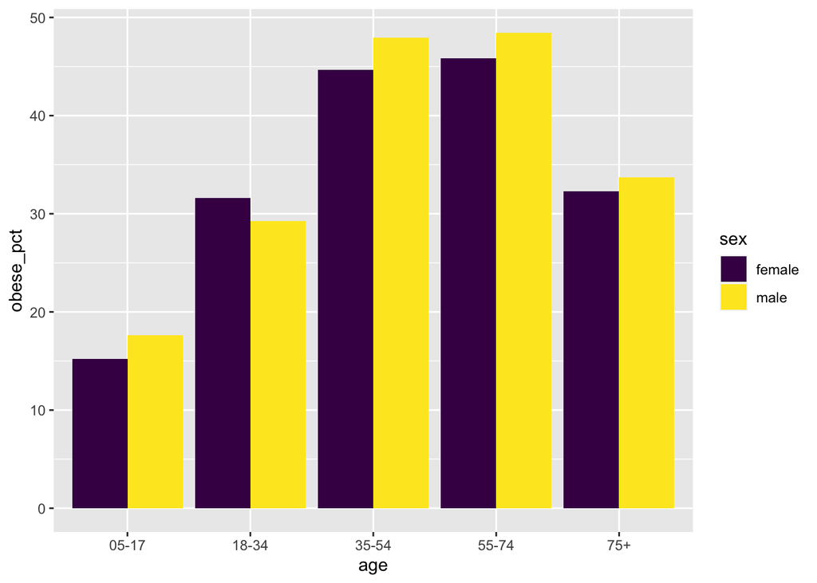

```r
ggplot(prob7, aes(x=age, y = obese_pct, fill=sex)) +
  geom_col(position = "dodge")
```

> Comment on patterns.

#### (a)

> Are differences between male and female obesity rates similar for all age groups? If not, can you give a possible reason to explain the difference?
- In most age groups, the obesity of males is slightly higher than that of females.
- The one exception is 18-34 years of age.
- The most plausible explanation is that some women will be pregnant during these ages and will be labeled as obese while pregnant, even if they are not typically.

#### (b)

> Why are the obesity rates in children so different than in adults? Provide a reason.
- The definition of obesity is very different for children (be among the top 5% of BMI for age and sex) than it is for adults (have a BMI of 30 or higher).

#### (c)

> Describe how obesity rates change among men and women as the population ages. What possible factor best explains the difference between obseity rates among those aged 55-74 and those 75 and older, do you think?
- The most plausible explanation is differential survival rate. A larger percentage of obese people die before reaching age 75 than do non-obese people.

### Read the Data

- Read the Wisconsin rural/urban data from *wi-urban-rural.csv*.

```r
ru = read_csv("../../data/wi_urban_rural.csv")

head(ru)
```

```
## # A tibble: 6 × 9
##   Id               Id2 Geography   `Total:` `Urban:` `Urban: - Insid… `Urban: - Insid…
##   <chr>          <dbl> <chr>          <dbl>    <dbl>            <dbl>            <dbl>
## 1 8600000US53001 53001 ZCTA5 53001     1901        0                0                0
## 2 8600000US53002 53002 ZCTA5 53002     2299        0                0                0
## 3 8600000US53003 53003 ZCTA5 53003      141        0                0                0
## 4 8600000US53004 53004 ZCTA5 53004     3330        0                0                0
## 5 8600000US53005 53005 ZCTA5 53005    19425    19425            19425                0
## 6 8600000US53006 53006 ZCTA5 53006     1779        0                0                0
## # … with 2 more variables: Rural <dbl>, Not defined for this file <dbl>
```

### Understanding the Rural/Urban Data

- The US Census Bureau areas as rural or urban based on population density.
- Rural areas are open country or settlements with fewer than 2,500 residents.
- Urban areas are more densely settled areas and need not follow municipal boundaries.
- A single zip code might contain both rural and urban areas.
- The Wisconsin rural/urban data set we read in has nine columns, but we are only interested in three of these.
  - `Id2` which is the zip code
  - `Urban:` which is the population that lives in urban areas
  - `Rural` which is the population that lives in rural areas
- The variable `Total:` is the sum of these two, but we can sum these ourselves if needed.
- The urban totals are subdivided, but we only need the total.

#### Transform the Rural/Urban Data

- We transform the data so that there are only these three columns and we rename them.
- We also change zip to character valued so it will match the same column in the obesity data.

```r
ru = ru %>%
  select(Id2, `Urban:`, Rural) %>%
  rename(zip = Id2,
         urban = `Urban:`,
         rural = Rural) %>%
  mutate(zip = as.character(zip))

head(ru)
```

```
## # A tibble: 6 × 3
##   zip   urban rural
##   <chr> <dbl> <dbl>
## 1 53001     0  1901
## 2 53002     0  2299
## 3 53003     0   141
## 4 53004     0  3330
## 5 53005 19425     0
## 6 53006     0  1779
```

### Merging the Data

```r
## Summarize the Obesity Data by Zip Code
obesity2 = obesity %>%
  drop_na() %>%
  group_by(zip) %>%
  summarize(pop = sum(pop),
            obese_pop = sum(obese_pop),
            non_obese_pop = sum(non_obese_pop))

head(obesity2)
```

```
## # A tibble: 6 × 4
##   zip     pop obese_pop non_obese_pop
##   <chr> <dbl>     <dbl>         <dbl>
## 1 53001  1353      589.          764.
## 2 53002  2412      829.         1583.
## 3 53004  2408     1157.         1251.
## 4 53005 15189     4632.        10557.
## 5 53006   458      167.          291.
## 6 53007  1437      607.          830.
```

- Notice that the `obesity2` data set only has data from 581 of the 774 Wisconsin zip codes.
- Next, we want to join the rural/urban data with the obesity data by zip code.
- We will keep the obesity data as primary, and add the `rural` and `urban` columns for the remaining zip codes.
- Note the use of `left_join()`.

```r
obesity2 = obesity2 %>%
  left_join(ru, by = "zip")

head(obesity2)
```

```
## # A tibble: 6 × 6
##   zip     pop obese_pop non_obese_pop urban rural
##   <chr> <dbl>     <dbl>         <dbl> <dbl> <dbl>
## 1 53001  1353      589.          764.     0  1901
## 2 53002  2412      829.         1583.     0  2299
## 3 53004  2408     1157.         1251.     0  3330
## 4 53005 15189     4632.        10557. 19425     0
## 5 53006   458      167.          291.     0  1779
## 6 53007  1437      607.          830.  1841     0
```

### Obesity Rate versus Urbanization

- Next, let’s calculate the proportion of obese people and the proportion of people living in urban areas for each zip code and add columns with this data.

```r
obesity2 = obesity2 %>%
  mutate(p_obese = obese_pop / (obese_pop + non_obese_pop),
         p_non_obese = 1 - p_obese,
         p_urban = urban / (urban + rural),
         p_rural = 1 - p_urban)

head(obesity2)
```

```
## # A tibble: 6 × 10
##   zip     pop obese_pop non_obese_pop urban rural p_obese p_non_obese p_urban
##   <chr> <dbl>     <dbl>         <dbl> <dbl> <dbl>   <dbl>       <dbl>   <dbl>
## 1 53001  1353      589.          764.     0  1901   0.435       0.565       0
## 2 53002  2412      829.         1583.     0  2299   0.344       0.656       0
## 3 53004  2408     1157.         1251.     0  3330   0.481       0.519       0
## 4 53005 15189     4632.        10557. 19425     0   0.305       0.695       1
## 5 53006   458      167.          291.     0  1779   0.366       0.634       0
## 6 53007  1437      607.          830.  1841     0   0.422       0.578       1
## # … with 1 more variable: p_rural <dbl>
```

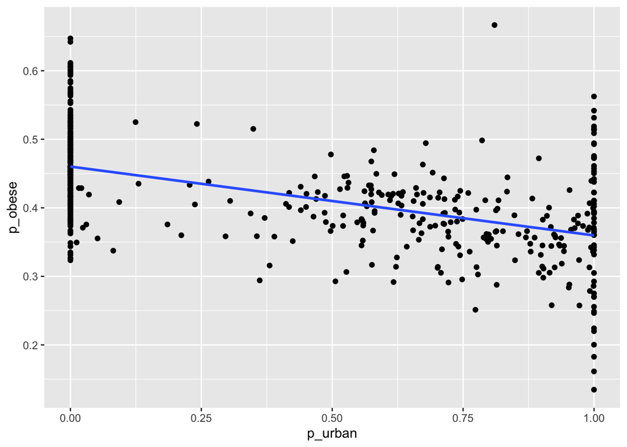

```r
ggplot(obesity2, aes(x=p_urban, y=p_obese)) +
  geom_point() +
  geom_smooth(se = FALSE, method = "lm")
```

#### Observations

- Many zipcodes are either 100% urban or 100% rural.
- There is a tendency for a greater obesity prevalence in more rural zip codes
- There is considerable variation from zip code to zip code
- The plot may be improved in many ways:
  - axis labels and titles
  - scales
  - include population data?

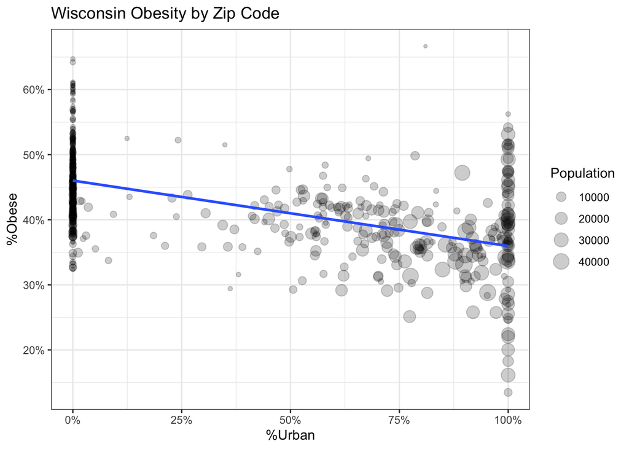

```r
library(scales)
ggplot(obesity2, aes(x=p_urban, y=p_obese, size=pop)) +
  geom_point(alpha = 0.2) +
  geom_smooth(se = FALSE, method = "lm", show.legend = FALSE) +
  ## represent the x and y axes with percentages
  ## accuracy = 1 means round to a whole number
  ##   (use accuracy = 0.1 or 0.2, for example, to round to one digit)
  scale_x_continuous(labels = percent_format(accuracy = 1)) +
  scale_y_continuous(labels = percent_format(accuracy = 1)) +
  ## Change the legend title from "pop" to "Population"
  scale_size_continuous(name = "Population") +
  xlab("%Urban") +
  ylab("%Obese") +
  ggtitle("Wisconsin Obesity by Zip Code") +
  ## change the background to white
  theme_bw()
```